# Random forests in practice

A guided analysis of accent features

Dr Massimiliano Canzi

# Random forests in practice

`Did you know:` a single Eurasian jay hides several thousand acorns in autumn, mainly in October, and feeds on them through winter, spring and early summer.

*Source: Bossema (1979), Behaviour*

## How this session works

As in lecture 4: you work on your own or in pairs, the task slides say what to do, checkpoints show what you should get, and the solutions are in the source of these slides, `source/06_random_forests_practical.qmd` at github.com/mcanzi/advanced_statistics. The tutorial sheet for this session: `konstats::get_tutorial(6, ".", course = "advanced")`.

Today’s data hide a trap that is easy to fall into with grouped data. See whether you find it before the slides point it out.

## The study

`accent` from {simling}: a simulated accent study in which 30 speakers, 15 with English as their L1 and 15 Italian learners of English, read 40 English words each. Six acoustic measures per token:

| Variable | What it measures |
| --- | --- |
| `vot` | voice onset time of the initial /p t k/ (ms) |
| `vowel_ratio` | duration of a stressed vowel relative to an unstressed one |
| `rate` | speech rate (syllables per second) |
| `f0` | mean fundamental frequency (Hz) |
| `h1h2` | H1–H2, a measure of voice quality (dB) |
| `intensity` | mean intensity (dB) |

## The data

```r
accent
```

```
# A tibble: 1,200 × 9
  speaker l1      gender   vot vowel_ratio  rate    f0  h1h2 intensity
  <fct>   <fct>   <fct>  <dbl>       <dbl> <dbl> <dbl> <dbl>     <dbl>
1 S01     English female   103        1.79  5.76   188   2.6      61.8
2 S01     English female    76        1.27  5.68   200   3        70.5
3 S01     English female    83        1.73  6.31   191   5.3      69
4 S01     English female    85        1.67  5.26   211   2.6      67.6
# ℹ 1,196 more rows
```

`?accent` gives the true model. Leave it closed until you have finished the tasks.

## Task 1: look at the data

1. How many tokens are there per speaker and per group?
2. Compute speaker means for each measure, and plot them by L1. Which measures separate the groups?
3. What accuracy would you get by always guessing the same L1? This is your baseline

## Checkpoint 1

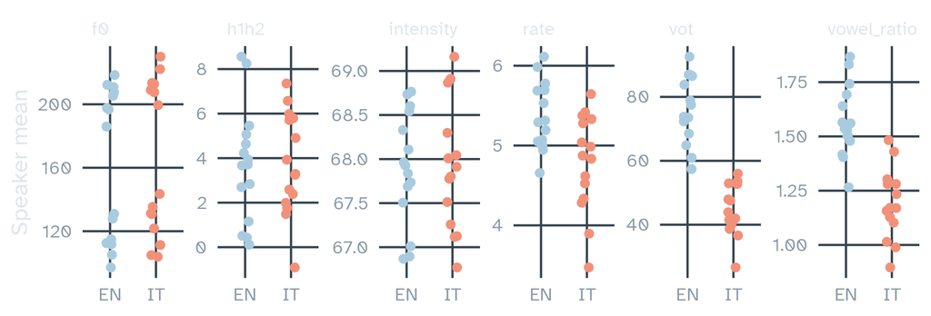

VOT, the vowel ratio and, less clearly, articulation rate differ between the groups. f0 mostly separates women from men. The baseline is 50%.

# A first forest

`Did you know:` a jay can carry up to six acorns on one trip. It swallows the first ones and carries the last in its bill, and the more acorns it carries, the farther it flies before hiding them.

*Source: Bossema (1979), Behaviour*

## Task 2: fit a forest

```r
f_all <- l1 ~ vot + vowel_ratio + rate + f0 + h1h2 + intensity
rf_all <- ranger(f_all, data = accent, num.trees = 1000, importance = ___, seed = 1)
rf_all
1 - rf_all$prediction.error
```

- Ask for permutation importance, as in lecture 5
- The last line is the OOB accuracy. How does it compare with the baseline?
- Plot the variable importance. Which predictors does the forest use most?

## Checkpoint 2

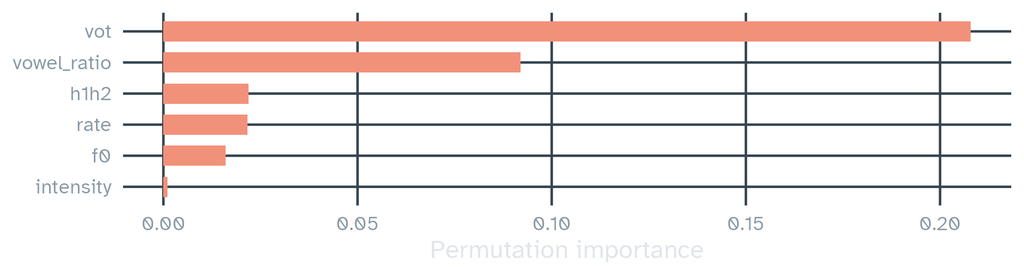

OOB accuracy: 0.907. Before you go on: f0 and H1–H2 have no link with L1 in the simulation. Why could the forest find them useful?

## Task 3: the trap

Every speaker’s 40 tokens are in the data. A tree’s bootstrap sample therefore almost always contains other tokens of the speaker whose OOB token it predicts.

- f0 and H1–H2 vary between speakers but little within them, like a speaker fingerprint. The forest can recognise the speaker and look up their L1
- That does not help with a new speaker, which is what the research question is about

The OOB error assumes independent observations. With grouped data, it rewards predictors that merely identify the group (Roberts et al., 2017).

## Speaker fingerprints

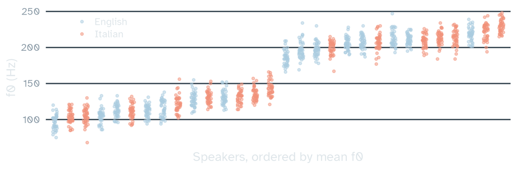

Each column holds one speaker’s 40 tokens. They cluster tightly, while English and Italian speakers are mixed along the whole range. A token’s f0 tells the forest who is speaking, and the speaker’s other tokens tell it the L1.

## Task 4: cross-validation by speaker

```r
set.seed(2)
folds <- distinct(accent, speaker, l1) |>
  mutate(fold = sample(rep(1:5, length.out = n())), .by = l1)
cv_speakers <- function(formula) {
  map(1:5, \(k) {
    train <- filter(accent, speaker %in% folds$speaker[folds$fold != k])
    test <- filter(accent, speaker %in% ___)
    m <- ranger(formula, data = train, num.trees = 500, seed = k)
    tibble(speaker = test$speaker, l1 = test$l1, pred = predict(m, test)$predictions)
  }) |> list_rbind()
}
```

Complete the test set, run `cv_speakers(f_all)`, and compute the accuracy on held-out speakers. Each fold leaves out three speakers from each group.

## Task 5: fewer predictors

Refit with only the three measures that differed between the groups in Task 1: `vot`, `vowel_ratio` and `rate`.

1. Compare the OOB accuracy and the speaker-wise cross-validated accuracy of both forests
2. Which forest would you trust for new speakers?

## Checkpoint 3

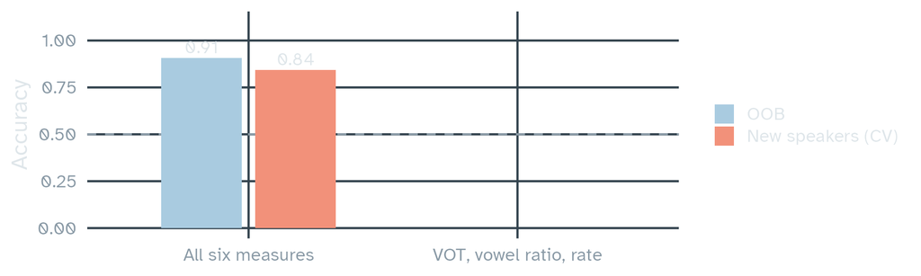

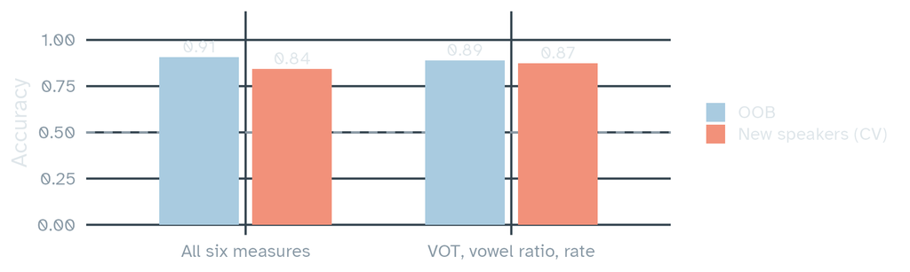

Only cross-validation by speaker estimates how well the forest classifies speakers it has not seen. The dashed line is the baseline.

# From tokens to speakers

`Did you know:` many oak seedlings grow from acorns that jays hid the autumn before. Bossema could tell from the bill prints left on the shells.

*Source: Bossema (1979), Behaviour*

## Task 6: classify speakers

The research question asks about speakers, so the last step goes from tokens to people. Use the cross-validated predictions of the three-measure forest:

- For each held-out speaker, take the L1 that most of their 40 tokens were assigned to
- How many of the 30 speakers are classified correctly? How does this compare with the token accuracy?

## Task 7: how do the measures matter?

Fit a probability forest with the three measures on all data, and draw a partial dependence plot for VOT, as in lecture 5.

```r
rf_prob <- ranger(f_l1, data = accent, num.trees = 500, probability = ___, seed = 1)
```

- In which VOT range does the predicted probability of an Italian L1 change most?
- Does that match what you know about VOT in English and Italian?

## Checkpoint 4

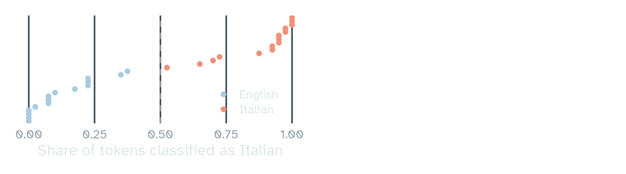

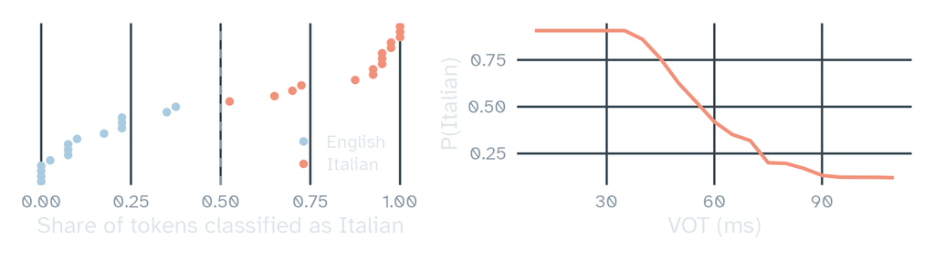

30 of 30 held-out speakers classified correctly by majority vote.

## Task 8: report

Write a short methods and results paragraph. It should say:

- the number of trees, `mtry` and the seed, and why you chose the predictors you kept
- how accuracy was estimated, and why OOB accuracy was not enough
- token and speaker accuracy against the baseline, and what the partial dependence plot shows

Could a reviewer object to anything in your paragraph? If you work with others, swap paragraphs and check each other’s.

## If you finish early

- Tune `mtry` for the three-measure forest, using speaker-wise cross-validation and not the OOB error
- Fit `lme4::glmer(l1 ~ scale(vot) + scale(vowel_ratio) + scale(rate) + (1 | speaker), family = binomial)`. What does the mixed model tell you that the forest does not, and what does it fail to see?

## Summary

- Compare every accuracy with a baseline
- When observations are grouped, the OOB error is too optimistic: features that identify the group let the forest look up the answer
- Use cross-validation by group, here by speaker, whenever the question is about new speakers, items or texts
- Choose predictors from the research question, and report importance, partial dependence and the validation scheme

## References

- Roberts, D. R., Bahn, V., Ciuti, S., Boyce, M. S., Elith, J., Guillera-Arroita, G., Hauenstein, S., Lahoz-Monfort, J. J., Schröder, B., Thuiller, W., Warton, D. I., Wintle, B. A., Hartig, F., & Dormann, C. F. (2017). Cross-validation strategies for data with temporal, spatial, hierarchical, or phylogenetic structure. *Ecography*, 40(8), 913–929. https://doi.org/10.1111/ecog.02881
- Strobl, C., Malley, J., & Tutz, G. (2009). An introduction to recursive partitioning: Rationale, application, and characteristics of classification and regression trees, bagging, and random forests. *Psychological Methods*, 14(4), 323–348. https://doi.org/10.1037/a0016973
- Wright, M. N., & Ziegler, A. (2017). ranger: A fast implementation of random forests for high dimensional data in C++ and R. *Journal of Statistical Software*, 77(1), 1–17. https://doi.org/10.18637/jss.v077.i01

## Sources of the animal facts

- Bossema, I. (1979). Jays and oaks: An eco-ethological study of a symbiosis. *Behaviour*, 70(1–2), 1–116. https://doi.org/10.1163/156853979X00016

## Slides and code

[figure not shown]

These slides

mcanzi.de/advanced_statistics/06_random_forests_practical.html

Code and all lectures

github.com/mcanzi/advanced_statistics